# Best Selling Game Consoles

```
## [1] "C:/Users/Bruno Borges/Documents/BACKUP BRUNO/Meus Documentos/Estudos/R/Best-Selling Game Consoles"
```

```
## [1] "C:/Users/Bruno Borges/Documents/BACKUP BRUNO/Meus Documentos/Estudos/R/Best-Selling Game Consoles/data-raw/best-selling game consoles.csv"
```

## Objective

Analyze the total selling of consoles along the year separated by company.

## About Dataset

### Description:

This [dataset](https://www.kaggle.com/datasets/tayyarhussain/best-selling-game-consoles-of-all-time?select=best-selling+game+consoles.csv) contains information about the best-selling game consoles of all time. The data includes the console name, manufacturer, release year, total units sold, and some other information. The dataset covers a wide range of consoles, from the earliest releases to the current generation of consoles.

### Columns:

- Console Name: The name of the game console.
- Type: The type of console (e.g., home console, handheld console).
- Company: The company that manufactured the console.
- Released Year: The year in which the console was first released.
- Discontinuation Year: The year in which the console was discontinued (if applicable).
- Units Sold (million): The total number of units sold worldwide, in millions.
- Remarks: Any additional remarks or comments about the console (if applicable).

The dataset can be used to analyze the popularity of different game consoles over time. It can also be used to identify trends in the gaming industry and to compare the performance of different manufacturers. Researchers, game developers, and marketers can benefit from this dataset to make informed decisions based on the past performance of game consoles in the market.

| Console Name | Type | Company | Released Year | Discontinuation Year | Units sold (million) | Remarks |
| --- | --- | --- | --- | --- | --- | --- |
| PlayStation 2 | Home | Sony | 2000 | 2013 | 155.00 | Final sales are greater than 155 million |
| Nintendo DS | Handheld | Nintendo | 2004 | 2013 | 154.02 | NA |
| Nintendo Switch | Hybrid | Nintendo | 2017 | 0 | 122.55 | NA |
| Game Boy | Handheld | Nintendo | 1989 | 2003 | 64.42 | The Game Boy (1989) and the Game Boy Color (1998) combined have sold 118.69 million units worldwide |
| Game Boy Color | Handheld | Nintendo | 1998 | 2003 | 44.06 | NA |
| PlayStation 4 | Home | Sony | 2013 | 0 | 117.20 | NA |

## Data Wrangling

Total selling per company by year.

| Released Year | Company | Selling |
| --- | --- | --- |
| 2020 | Microsoft | 18.50 |
| 2020 | Sony | 30.00 |
| 2017 | Nintendo | 127.83 |
| 2016 | Nintendo | 3.56 |
| 2013 | Microsoft | 58.50 |
| 2013 | Sony | 117.20 |
| 2012 | Nintendo | 13.56 |
| 2011 | Nintendo | 75.94 |
| 2011 | Sony | 15.00 |
| 2006 | Nintendo | 101.63 |
| 2006 | Sony | 87.40 |
| 2005 | Microsoft | 84.00 |
| 2004 | Nintendo | 154.02 |
| 2004 | Sony | 82.00 |
| 2003 | Nokia | 3.00 |
| 2001 | Microsoft | 24.00 |
| 2001 | Nintendo | 103.25 |
| 2000 | Sony | 155.00 |
| 1999 | Bandai | 3.50 |
| 1998 | Nintendo | 44.06 |
| 1998 | Sega | 9.13 |
| 1996 | Nintendo | 32.93 |
| 1994 | Sega | 9.26 |
| 1994 | Sony | 102.49 |
| 1993 | Sega | 3.40 |
| 1992 | Micro Genius | 6.00 |
| 1991 | Sega | 2.24 |
| 1990 | Nintendo | 49.10 |
| 1990 | Philips | 1.00 |
| 1990 | Sega | 10.62 |
| 1990 | Tectoy | 3.00 |
| 1989 | Atari | 1.00 |
| 1989 | Nintendo | 64.42 |
| 1989 | Tectoy | 8.00 |
| 1988 | NEC | 1.92 |
| 1988 | Sega | 30.75 |
| 1987 | NEC/Hudson Soft[note 6] | 10.00 |
| 1986 | Atari | 1.00 |
| 1986 | Nintendo | 4.50 |
| 1986 | Sega | 13.00 |
| 1983 | Nintendo | 61.91 |
| 1982 | Atari | 1.00 |
| 1982 | Coleco | 2.00 |
| 1980 | Mattel | 3.00 |
| 1980 | Nintendo | 43.40 |
| 1978 | Magnavox/Philips | 2.00 |
| 1977 | Atari | 30.00 |
| 1977 | Nintendo | 3.00 |
| 1976 | Coleco | 1.00 |

## Visualization

Total selling across the years

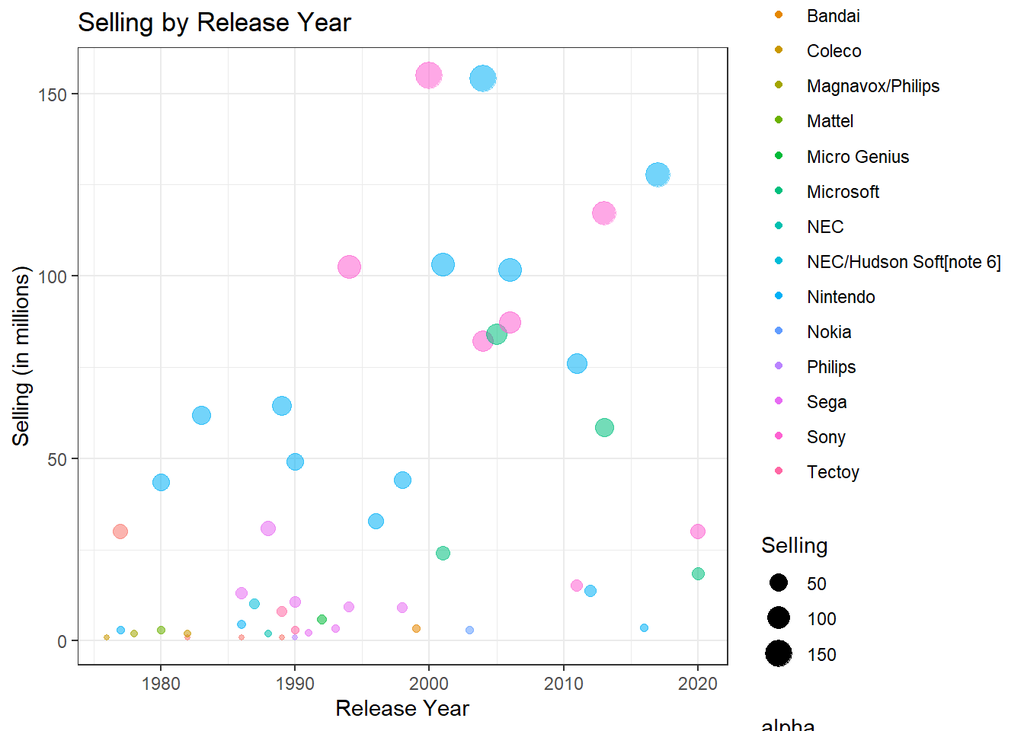

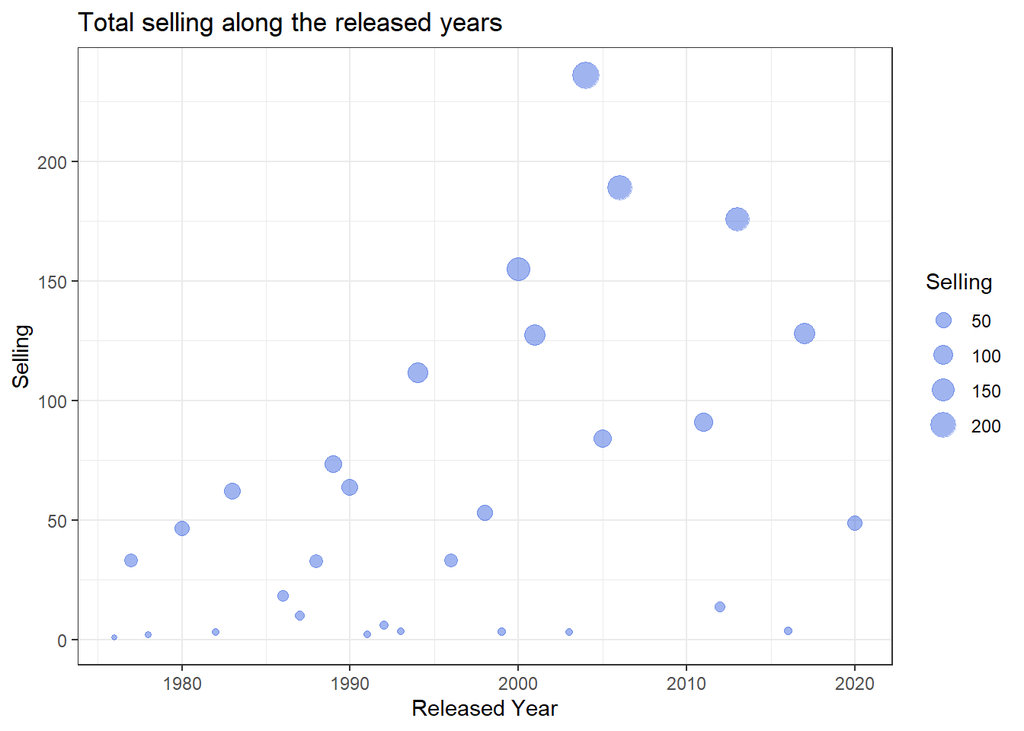

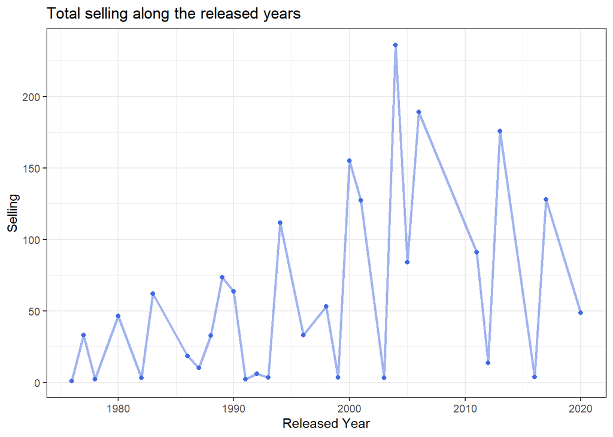